# Simulation Study

Alessandro Colombi

# 0 - Osservazioni

Provo a spiegare l’evidenza osservata:

- Dal punto di vista della marginale $m(X)$, la $P_0$ scelta con iperparametri scelti con empirical Bayes sembra molto bella perché abbraccia bene i dati. Se scelgo invece “a caso” ho una $m(X)$ schiacciata solo sui dati vicini allo zero (perché metto $\mu_0 = 0$), quindi sembra piuttosto brutta.
- Dal punto di vista delle medie a posteriori, abbiamo

$\mu_k | X_1,\dots,X_n \sim N(\frac{n_k}{n_k + k_0}\bar{X_k} + \frac{k_0}{n_k + k_0}\mu_0 )$

$\sigma^2_k | X_1,\dots,X_n \sim InvGamma(\frac{\nu_0 + n_k}{2}, \frac{1}{2}(\nu_0\sigma_0^2 + (n_k-1)V_k + \frac{n_k k_0}{n_k + k_0}(\bar{X}_k - \mu_0)^2))$

dove $n_k$ è la numerosità, $\bar{X}_k$ è la media campionaria e $V_k$ è la varianza campionaria del cluster $k$. In particolare, con empircal bayes vengono dei valori molto alti di $k_0$ e quindi per esempio il peso legato alla prior nella media a posteriori è molto simile a quello dato all’evidenza dei dati $\frac{n_k}{n_k + k_0} \approx \frac{k_0}{n_k + k_0}$. Per la varianza invece viene $\nu_0\sigma_0^2$ molto più alto degli altri termini.

- Quindi, dalla media a posteriori mi viene da dire che sarebbe meglio avere $k_0$ basso in modo da essere meno informativi sulla media
  - In Empirical Bayes mettiamo $k_0 = \frac{\bar{\sigma^2}}{\bar{V_\mu}}$, quindi è meglio aumentare $\bar{V_\mu}$. Per i ragionamenti che ho fatto sulla varianza, vuol dire diminuire un po’ la varianza di $X$. Bello che $k_0$ sia l’unico valore a dipendere da $\bar{V_{\mu}}$, quindi posso regolarlo direttamente.
- Per $\nu_0$ viene scelto un valore enorme, tipo $2700$. Quindi in $\sigma_k$ conta solo la parte dalla prior
  - Per contenere $\nu$ posso aumentare $\bar{V_\sigma}$, ha anche un po’ di impatto su $\sigma_0^2$.
  - Per ridurre tutto, si può lavorare anche sul parametro di correzione: per fare matching dei momenti, metto $E[\sigma^2] = \bar{\sigma^2}/correction$. Seguendo il lavoro di Raf avevo sempre considerato $correction = 3$ ma penso sia meglio alzarlo.
- La contraddizione però resta, tutti questi interventi hanno reso la $m(X)$ molto più concentrata invece che diffusa

# 1 - Casarin-Bassetti

## Data Generation

```r
suppressWarnings(suppressPackageStartupMessages(library(GDFMM)))
suppressWarnings(suppressPackageStartupMessages(library(ACutils)))
suppressWarnings(suppressPackageStartupMessages(library(tidyverse)))
suppressWarnings(suppressPackageStartupMessages(library(RColorBrewer)))
suppressWarnings(suppressPackageStartupMessages(library(salso)))
suppressWarnings(suppressPackageStartupMessages(library(wesanderson)))
suppressWarnings(suppressPackageStartupMessages(library(mcclust.ext)))
```

```r
mycol = hcl.colors(n=3,palette = "Zissou1")

d = 3                   # number of groups
K = 3                   # number of global clusters
mu = c(-5,0,5)          # vectors of means
sd = c(1,1,1)           # vector of sd
n_j = c(100,50,50)      # set cardinality of the groups

mix_probs = matrix(c(3/10,3/10,4/10,
                     3/10,7/10,   0,
                     8/10,1/10,1/10), nrow = d, ncol = K, byrow = T)
seed = 20051131

genD = simulate_data(d = d, K = K, p = mix_probs, mu = mu, sd = sd, n_j = n_j, seed = seed)
data = genD$data
real_partition = genD$real_partition

mycol_cluster = brewer.pal(n=K, name = "Dark2")
```

## Data Visualization

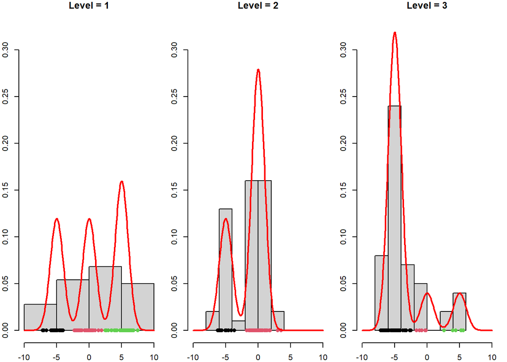

```r
idx_start = 1
idx_end = n_j[1]
xrange = c(-10,10)
l_grid = 200
grid = seq(xrange[1],xrange[2],length.out = l_grid)


par(mfrow = c(1,d), mar = c(2,2,1,1), bty = "l")
for(j in 1:d){
  mycol_cluster = brewer.pal(n=K, name = "Dark2")
  mycol_points  = as.factor(real_partition[idx_start:idx_end])
  levels(mycol_points) = unique(mycol_cluster)

  #dj = density(data[j,1:n_j[j]])

  hist(data[j,1:n_j[j]], freq = F, main = paste0("Level = ",j),
       xlim = xrange, ylim = c(0,0.33),
       nclass = "fd")

  points( x = data[j,1:n_j[j]], y = rep(0,n_j[j]),
          pch = 16, col = mycol_points)
  #lines(dj$x,dj$y, lwd = 2)
  points(grid, GDFMM::dmix(x = grid, w_j = mix_probs[j,], mu_vec = mu, sigma_vec = sd),
         col = "red", lwd = 2, type = "l")

  idx_start = idx_end + 1
  if(j<d){
    idx_end = idx_end + n_j[j+1]
  }
}
```

## Iperparametri $P_0$

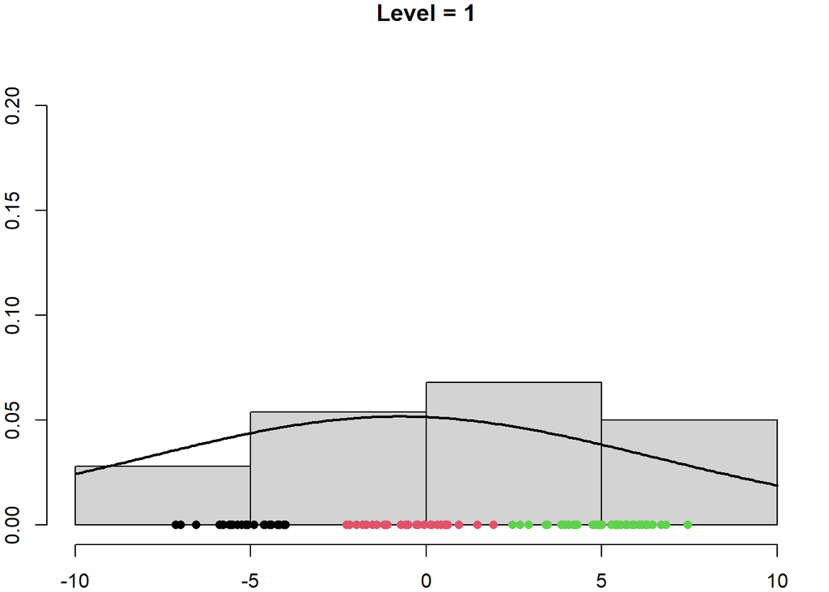

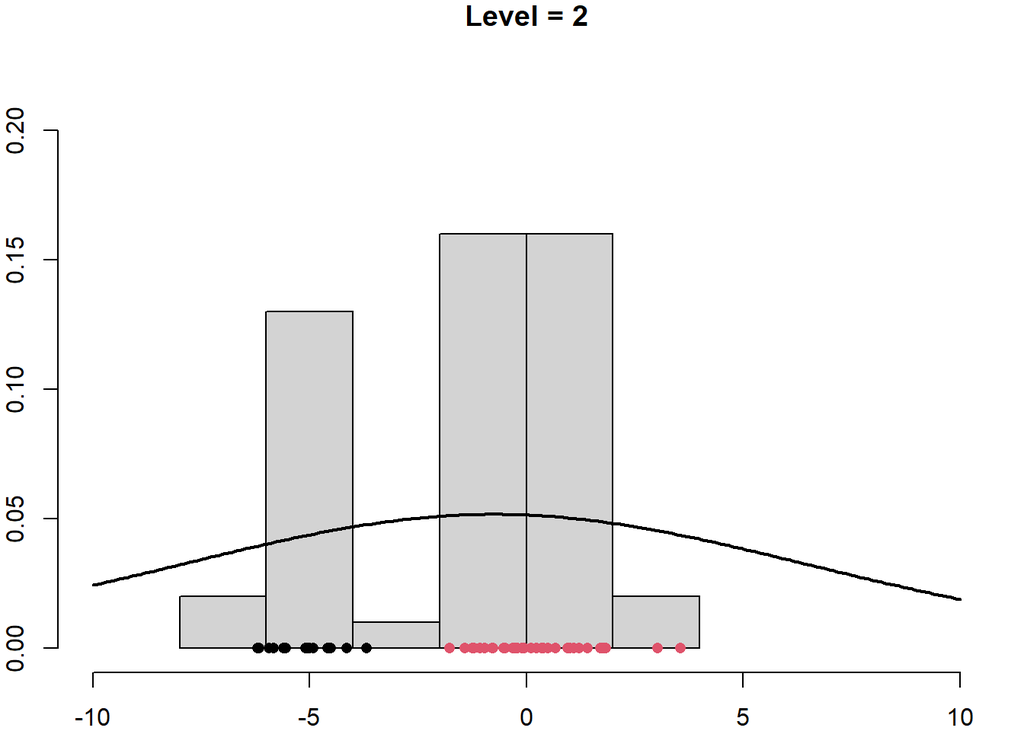

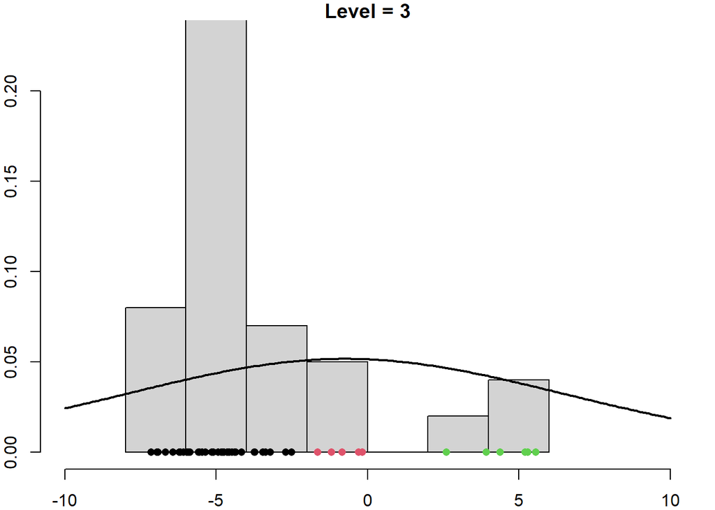

```r
xrange = c(-10,10)
l_grid = 200
grid = seq(xrange[1],xrange[2],length.out = l_grid)
# In questo plot sotto colori i pallini secondo il vero cluster.
idx_start = 1
idx_end = n_j[1]



# Calcolo anche la marginale trovata con i valori di Empirical Bayes e la plotto sopra
P0_hyparam = empirical_bayes_normalinvgamma(data = data )
mu0 = P0_hyparam$mu0;k0= P0_hyparam$k0;nu0=P0_hyparam$nu0;sigma0=P0_hyparam$sigma0
k0 = 0.1


scale = sqrt( (k0 + 1)/(k0) * sigma0 )
mean_marginal = mu0
var_marginal  = nu0/(nu0-2) * scale^2

Prior_grid = GDFMM:::dnct(x = grid, n0 = nu0, mu0 = mu0, gamma0 = scale)

for(j in 1:d){
  mycol_cluster = brewer.pal(n=K, name = "Dark2")
  mycol_points  = as.factor(real_partition[idx_start:idx_end])
  levels(mycol_points) = unique(mycol_cluster)


  par(mar = c(2,2,1,1), bty = "l")
  hist(data[j,1:n_j[j]], freq = F, main = paste0("Level = ",j),
       xlim = xrange, ylim = c(0,0.23),
       nclass = "fd")

  points( x = data[j,1:n_j[j]], y = rep(0,n_j[j]),
          pch = 16, col = mycol_points)
  points(grid, Prior_grid, col = "black", lwd = 2, type = "l")


  idx_start = idx_end + 1
  if(j<d){
    idx_end = idx_end + n_j[j+1]
  }
}
```

## Run

```r
# Run  --------------------------------------------------------------------
niter  <-  10000
burnin <-  6000
thin   <- 1

# tau
a_gamma <-   1; b_gamma  <- 1
a_lambda <- 10; b_lambda <- 2

option = set_options_marginal(
             "mu0" = mu0,"sigma0"= sigma0, "k0"= k0, "nu0"=nu0,
             "Adapt_MH_hyp1"= 0.7,"Adapt_MH_hyp2"= 0.234,
             "sp_mala_U" = 0.01, "sp_mala_gamma"=0.01,
             "gamma0" = 3,"Lambda0" = 10,
             "alpha_gamma"=a_gamma, "beta_gamma"=b_gamma,
             "alpha_lambda"=a_lambda, "beta_lambda"=b_lambda,
             "init_mean_cluster" = NULL,#unlist(mean_data_per_cluster),
             "init_var_cluster" = NULL,#unlist(var_data_per_cluster),
             "UpdateU" = T, "UpdateGamma" = T, "UpdateTau" = T, "UpdateLambda" = T,
             "partition" = seq(1,sum(n_j))
        )

# P0 Hyperparameters:
# old set: "mu0" = 0,"sigma0"= 1, "k0"= 1/10, "nu0"=10,
# new set: "mu0" = P0_hyparam$mu0, "k0"= P0_hyparam$k0, "nu0"=P0_hyparam$nu0, "sigma0"= P0_hyparam$sigma0,

# Process parameters
# old set:  "gamma0" = 1,"Lambda0" = 3,
#           "alpha_gamma"=5, "beta_gamma"=0.5, "alpha_lambda"=1, "beta_lambda"=5,


#GDFMM = GDFMM_sampler(data, niter, burnin, thin, seed = 123, option = option)
GDFMM = GDFMM_marginal_sampler(data, niter, burnin, thin, seed = 123, FixPartition = F, option = option)
```

[output not shown]

### Chains

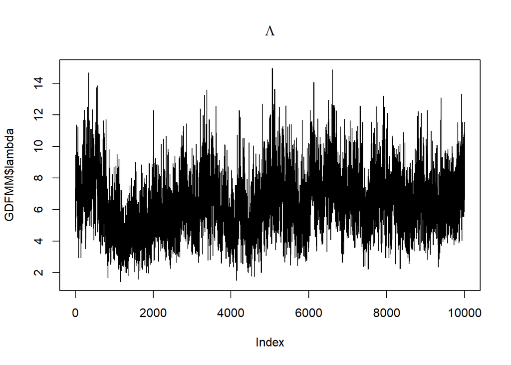

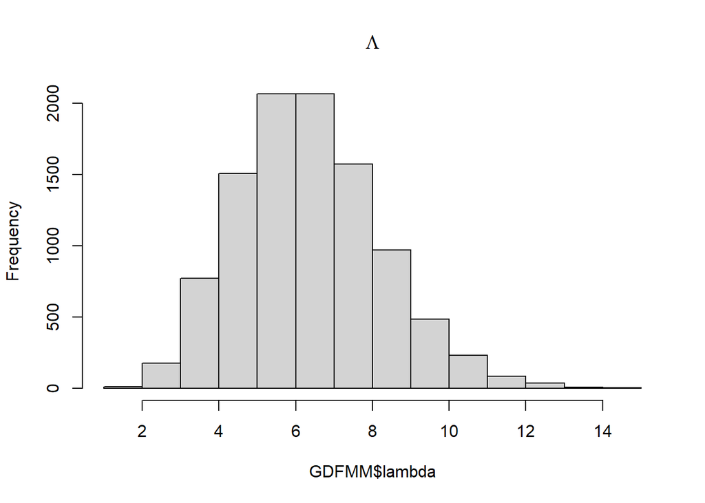

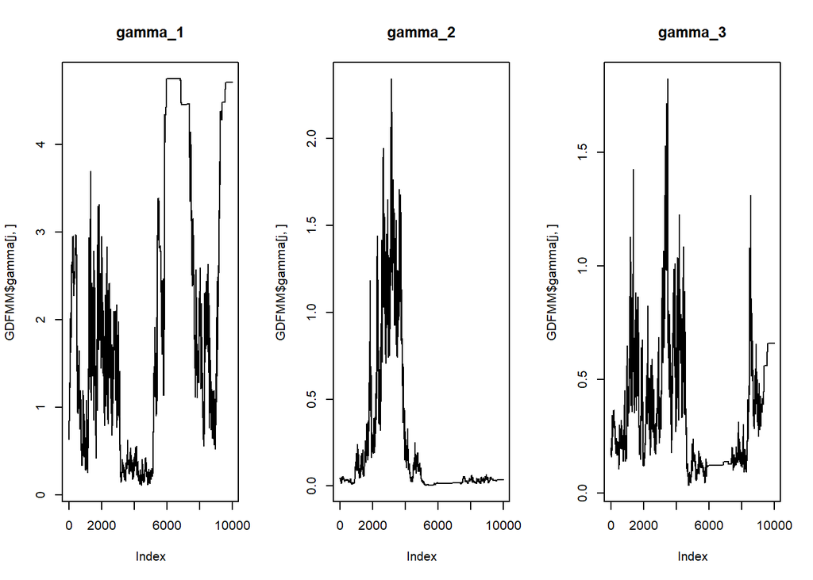

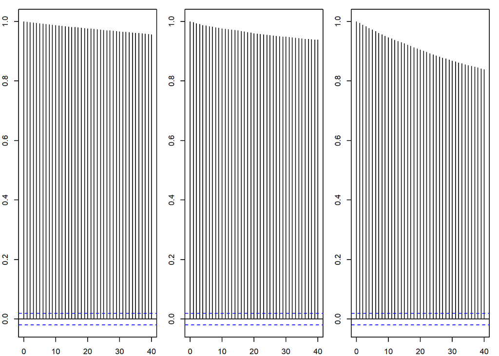

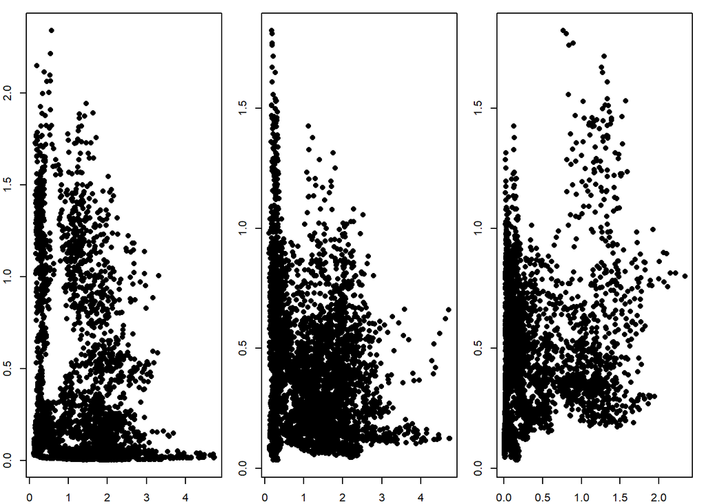

```
#> [1] -0.3629686
#> [1] -0.2895405
#> [1] 0.3919705
```

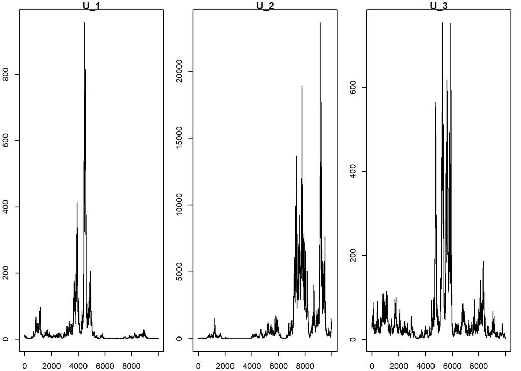

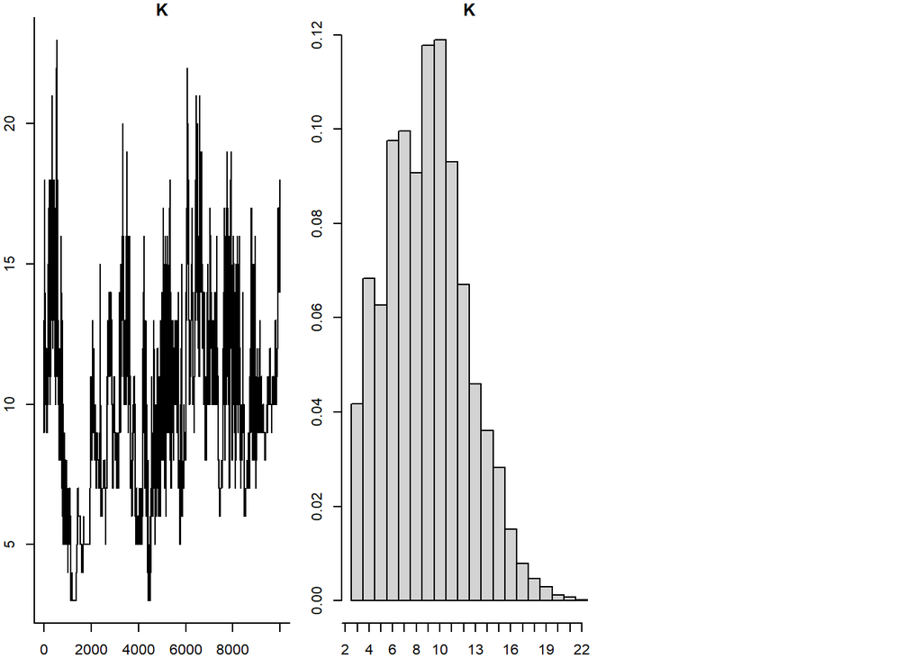

### Clustering

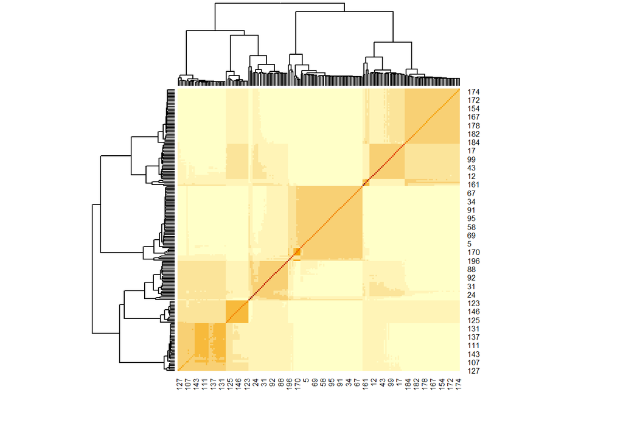

```r
# COMPUTE BINDER LOSS FUNCTION TO SELECT BEST PARTITION

# Get labels for each iterations for each data point
part_matrix <- GDFMM$Partition #GDFMM$Partition is a (n_iter x n_data) matrix

# Compute similarity matrix
sim_matrix <- psm(part_matrix)


heatmap(sim_matrix)
```

```r
binder_sara = minbinder(sim_matrix)
VI_sara = minVI(sim_matrix)

table(binder_sara$cl)
```

```
#>
#>  1  2  3  4  5  6  7  8  9 10 11 12 13 14 15 16 17 18 19 20 21 22 23 24 25 26
#> 44  1 12  1  1  1  1  1  1  1  1  1  1  1  1  1  1  2  1  1  1  1  1  1  1  1
#> 27 28 29 30 31 32 33 34 35 36 37 38 39 40 41 42 43 44 45 46 47 48 49 50
#>  1  1  1  1  1  1  1  1  1  1  1  1  1  1  1  1  1  1  1 16 34  6 39  5
```

```r
table(VI_sara$cl)
```

```
#>
#>  1  2  3
#> 53 78 69
```

```r
table(real_partition)
```

```
#> real_partition
#>  1  2  3
#> 80 67 53
```

```r
arandi(binder_sara$cl,real_partition)
```

```
#> [1] 0.4311975
```

```r
arandi(VI_sara$cl,real_partition)
```

```
#> [1] 0.7031347
```

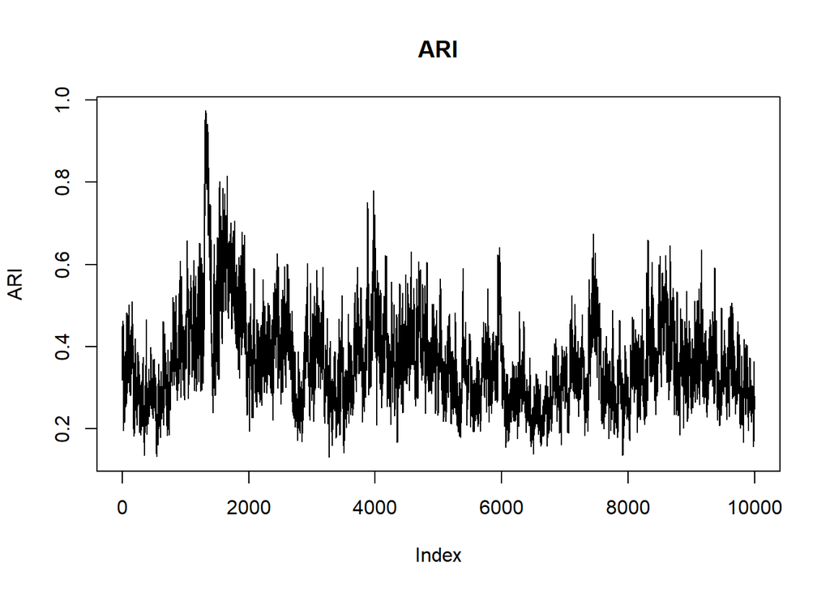

```r
ARI = apply( part_matrix, 1,
             FUN = function(part_it){
                      arandi(part_it,real_partition, adjust = T)
                  }
            )

plot(ARI, type = 'l', main = "ARI")
```

### Density estimation

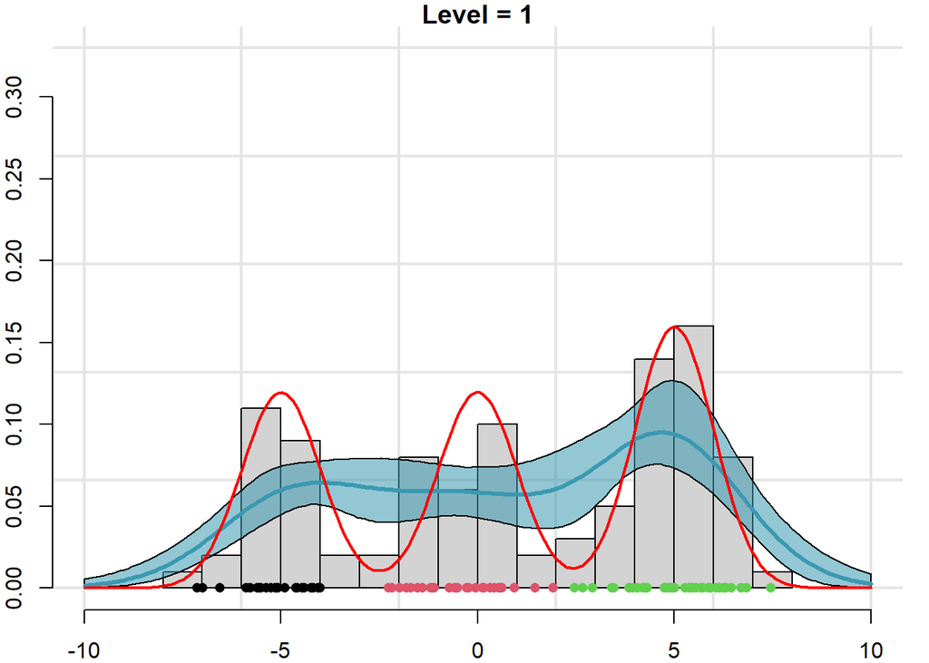

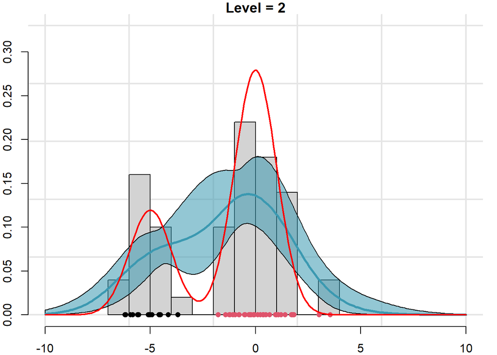

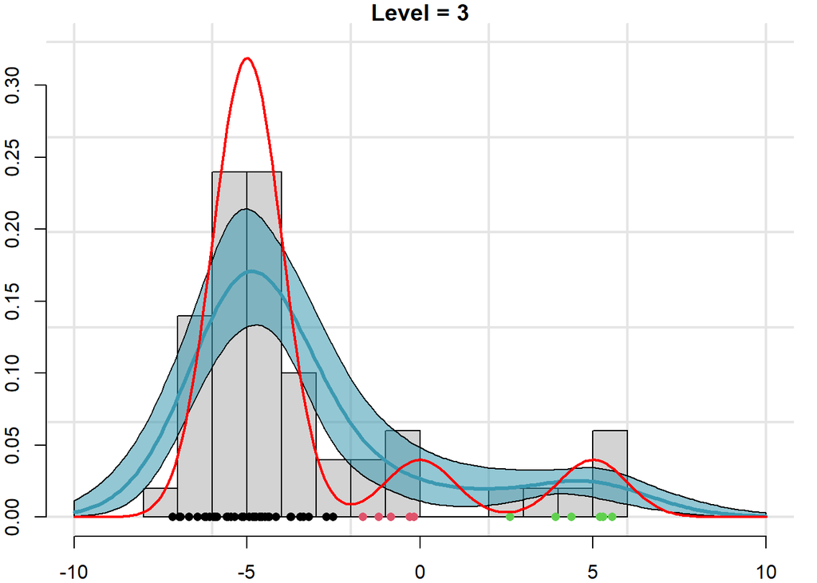

```r
xrange = c(-10,10)
l_grid = 200
grid = seq(xrange[1],xrange[2],length.out = l_grid)
# Predictive in all groups
Pred_all = predictive_marginal_all_groups(grid = grid, fit = GDFMM, burnin = 0, option = option)

# In questo plot sotto colori i pallini secondo il vero cluster.
idx_start = 1
idx_end = n_j[1]


#par(mfrow = c(1,d), mar = c(2,2,1,1))
par(mar = c(2,2,1,1), bty = "l")
for(j in 1:d){

  # set colors
  mycol_cluster = brewer.pal(n=K, name = "Dark2")
  mycol_points  = as.factor(real_partition[idx_start:idx_end])
  levels(mycol_points) = unique(mycol_cluster)

  # frequentist density
  dj = density(data[j,1:n_j[j]])
  yrange = range(Pred_all[[j]][3,]) + 0.001*max(Pred_all[[j]][3,])

  # Trick to add the grid below the plot
  plot.new()
  grid(lty = 1,lwd = 2,col = "gray90" )
  par(new = TRUE)

  # plot
  hist(data[j,1:n_j[j]], freq = F, breaks = n_j[j]/5,
       main = paste0("Level = ",j),
       ylim = c(0,0.33), xlim = xrange,
       ylab = "y-axis", xlab = "x-axis")
  points( x = data[j,1:n_j[j]], y = rep(0,n_j[j]),
          pch = 16, col = mycol_points)
  #lines(dj$x,dj$y, lwd = 3)
  #lines(x = grid, y = Pred_all[[j]][1,], col = "blue", lwd = 2, lty = 2) #0.025
  #lines(x = grid, y = Pred_all[[j]][3,], col = "blue", lwd = 2, lty = 2) #0.975
  polygon( c(grid, rev(grid)),
           c(Pred_all[[j]][1,], rev(Pred_all[[j]][3,])),
           col = ACutils::t_col(mycol[1], percent = 45))
  lines(x = grid, y = Pred_all[[j]][2,], col = mycol[1], lwd = 3) #0.5

  points(grid, dmix(x = grid, w_j = mix_probs[j,], mu_vec = mu, sigma_vec = sd),
         col = "red", lwd = 2, type = "l")

  idx_start = idx_end + 1
    if(j<d){
    idx_end = idx_end + n_j[j+1]
  }
}
```

# 2 - Cremaschi

**Dati esperimento:**

- **K = 3**
- d = 2
- $n_1 = 100$, $n_2 = 100$
- $\mu_1 = -3$, $\mu_2 = 0$, $\mu_3 = 1$
- $\sigma_1 = \sqrt{0.1}$, $\sigma_2 = \sqrt{0.5}$, $\sigma_3 = \sqrt{1.5}$
- $\pi_{11} = 2/10, \pi_{12} = 8/10, \pi_{13} = 0$
- $\pi_{21} = 0, \pi_{22} = 1/10, \pi_{23} = 9/10$

## Data Generation

```r
mycol = hcl.colors(n=3,palette = "Zissou1")


d = 2               # number of groups
K = 3               # number of global clusters
mu = c(-3,0,1)      # vectors of means
sd = c(sqrt(0.1), sqrt(0.5), sqrt(1.5) )     # vector of sd
prob <- matrix(c(0.2,0.8,  0,
                   0,0.1,0.9),nrow = d, ncol = K, byrow = T)

n_j = rep(100, d)  # set cardinality of the groups
seed = 20051131

#genD = generate_data_prob(d=d,p=prob, K=K, mu = mu, sd = sd, n_j = n_j, seed = seed)
genD = simulate_data(d=d,prob=prob, K=K, mu = mu, sd = sd, n_j = n_j, seed = seed)
data = genD$data
real_partition = genD$real_partition


table(real_partition)
```

```
#> real_partition
#>  1  2  3
#> 14 93 93
```

```r
table(real_partition[1:n_j[1]])
```

```
#>
#>  1  2
#> 14 86
```

```r
table(real_partition[(n_j[1]+1):(n_j[1] + n_j[2])])
```

```
#>
#>  2  3
#>  7 93
```

```r
mycol_cluster = brewer.pal(n=K, name = "Accent")
```

## Data Visualization

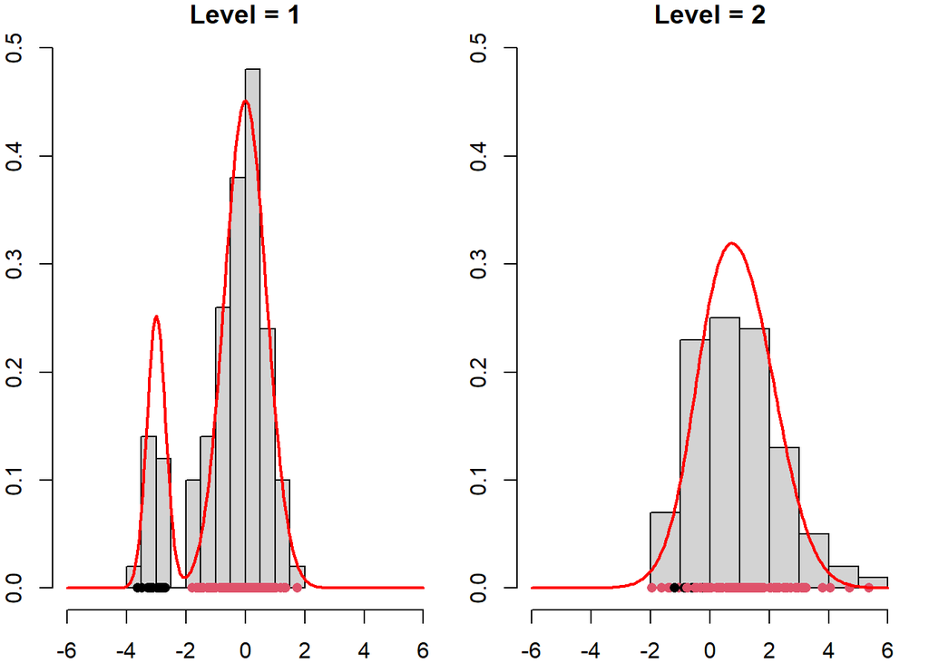

```r
idx_start = 1
idx_end = n_j[1]
xrange = c(-6,6)
l_grid = 200
grid = seq(xrange[1],xrange[2],length.out = l_grid)


par(mfrow = c(1,d), mar = c(2,2,1,1), bty = "l")
for(j in 1:d){
  mycol_cluster = brewer.pal(n=K, name = "Dark2")
  mycol_points  = as.factor(real_partition[idx_start:idx_end])
  levels(mycol_points) = unique(mycol_cluster)

  #dj = density(data[j,1:n_j[j]])

  hist(data[j,1:n_j[j]], freq = F, main = paste0("Level = ",j),
       xlim = xrange, ylim = c(0,0.5),
       nclass = "fd")

  points( x = data[j,1:n_j[j]], y = rep(0,n_j[j]),
          pch = 16, col = mycol_points)
  #lines(dj$x,dj$y, lwd = 2)
  points(grid, GDFMM::dmix(x = grid, w_j = prob[j,], mu_vec = mu, sigma_vec = sd),
         col = "red", lwd = 2, type = "l")

  idx_start = idx_end + 1
  if(j<d){
    idx_end = idx_end + n_j[j+1]
  }
}
```

## Iperparametri $P_0$

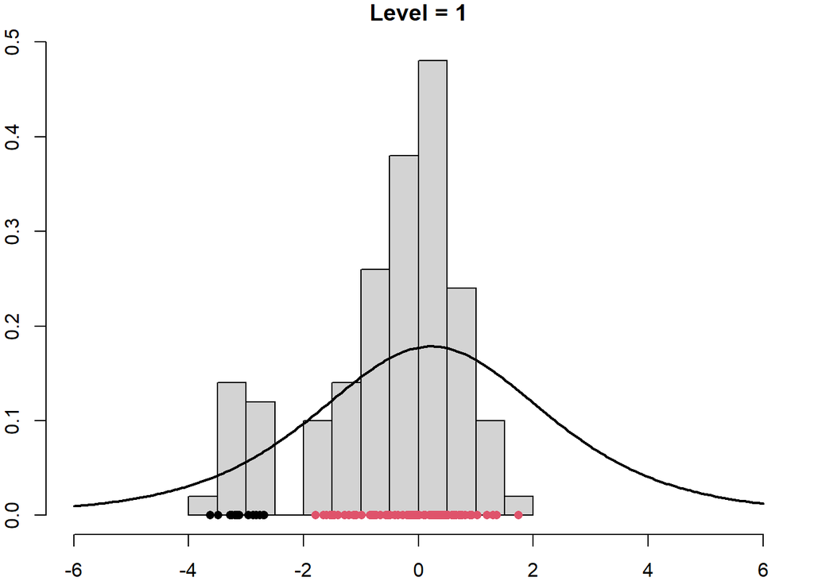

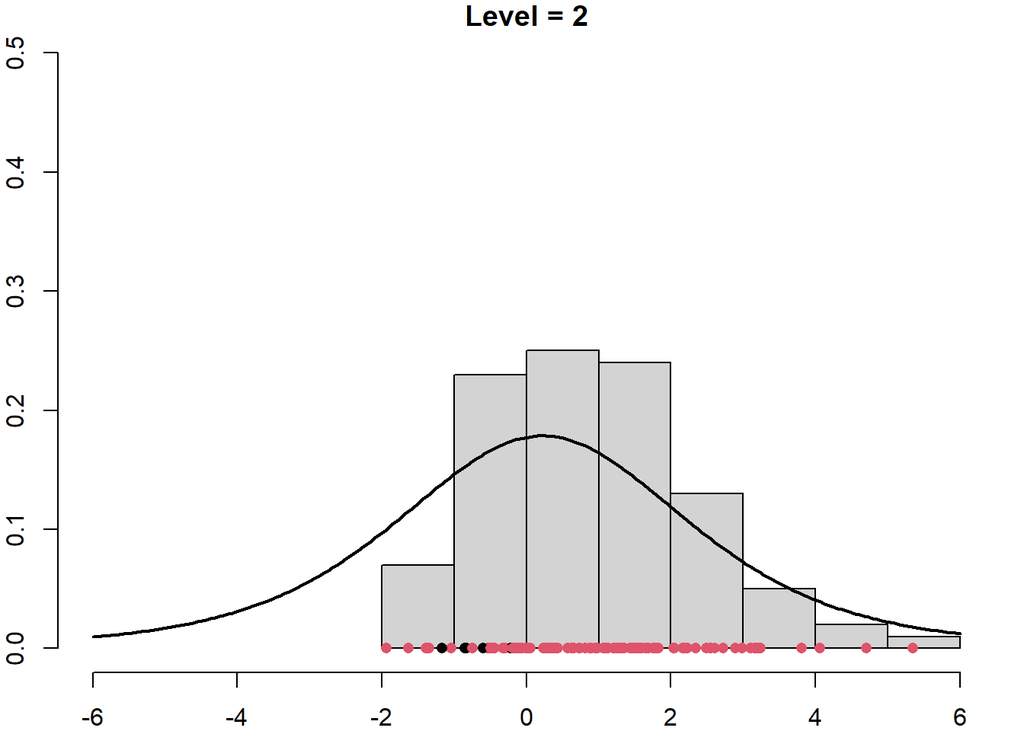

```r
xrange = c(-6,6)
l_grid = 200
grid = seq(xrange[1],xrange[2],length.out = l_grid)
# In questo plot sotto colori i pallini secondo il vero cluster.
idx_start = 1
idx_end = n_j[1]



# Calcolo anche la marginale trovata con i valori di Empirical Bayes e la plotto sopra
P0_hyparam = empirical_bayes_normalinvgamma(data = data )
mu0 = P0_hyparam$mu0;k0= P0_hyparam$k0;nu0=P0_hyparam$nu0;sigma0=P0_hyparam$sigma0
k0 = 0.1


scale = sqrt( (k0 + 1)/(k0) * sigma0 )
mean_marginal = mu0
var_marginal  = nu0/(nu0-2) * scale^2

Prior_grid = GDFMM:::dnct(x = grid, n0 = nu0, mu0 = mu0, gamma0 = scale)

for(j in 1:d){
  mycol_cluster = brewer.pal(n=K, name = "Dark2")
  mycol_points  = as.factor(real_partition[idx_start:idx_end])
  levels(mycol_points) = unique(mycol_cluster)


  par(mar = c(2,2,1,1), bty = "l")
  hist(data[j,1:n_j[j]], freq = F, main = paste0("Level = ",j),
       xlim = xrange, ylim = c(0,0.5),
       nclass = "fd")

  points( x = data[j,1:n_j[j]], y = rep(0,n_j[j]),
          pch = 16, col = mycol_points)
  points(grid, Prior_grid, col = "black", lwd = 2, type = "l")


  idx_start = idx_end + 1
  if(j<d){
    idx_end = idx_end + n_j[j+1]
  }
}
```

## Run

```r
# Run  --------------------------------------------------------------------
niter  <-  10000
burnin <-  6000
thin   <- 1

# tau
a_gamma <-   1; b_gamma  <- 1
a_lambda <- 10; b_lambda <- 2

option = set_options_marginal(
             "mu0" = mu0,"sigma0"= sigma0, "k0"= k0, "nu0"=nu0,
             "Adapt_MH_hyp1"= 0.7,"Adapt_MH_hyp2"= 0.234,
             "sp_mala_U" = 0.01, "sp_mala_gamma"=0.01,
             "gamma0" = 3,"Lambda0" = 10,
             "alpha_gamma"=a_gamma, "beta_gamma"=b_gamma,
             "alpha_lambda"=a_lambda, "beta_lambda"=b_lambda,
             "init_mean_cluster" = NULL,#unlist(mean_data_per_cluster),
             "init_var_cluster" = NULL,#unlist(var_data_per_cluster),
             "UpdateU" = T, "UpdateGamma" = T, "UpdateTau" = T, "UpdateLambda" = T,
             "partition" = seq(1,sum(n_j))
        )

# P0 Hyperparameters:
# old set: "mu0" = 0,"sigma0"= 1, "k0"= 1/10, "nu0"=10,
# new set: "mu0" = P0_hyparam$mu0, "k0"= P0_hyparam$k0, "nu0"=P0_hyparam$nu0, "sigma0"= P0_hyparam$sigma0,

# Process parameters
# old set:  "gamma0" = 1,"Lambda0" = 3,
#           "alpha_gamma"=5, "beta_gamma"=0.5, "alpha_lambda"=1, "beta_lambda"=5,


#GDFMM = GDFMM_sampler(data, niter, burnin, thin, seed = 123, option = option)
GDFMM = GDFMM_marginal_sampler(data, niter, burnin, thin, seed = 123, FixPartition = F, option = option)
```

[output not shown]

### Chains

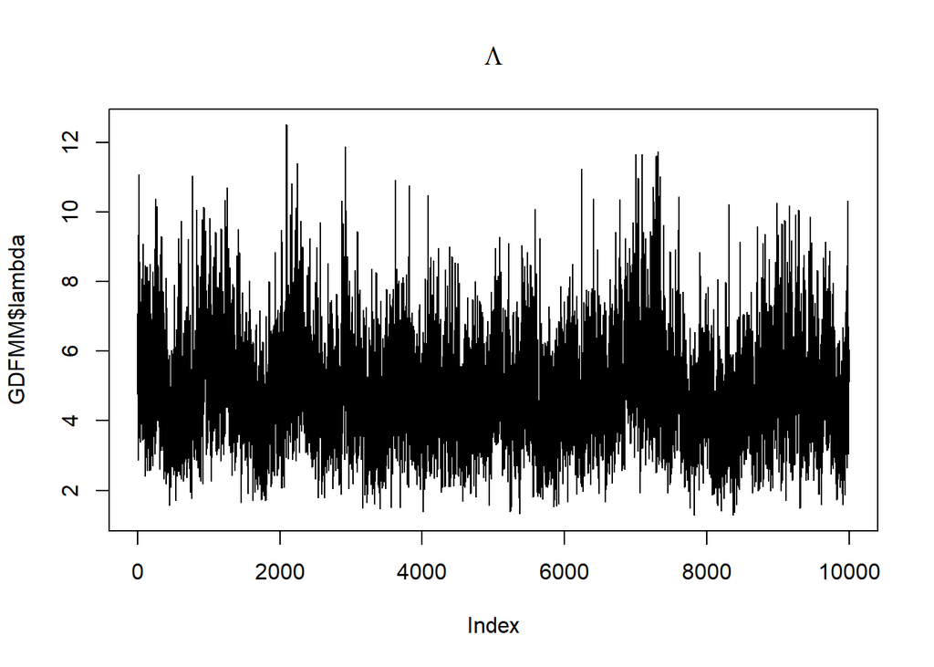

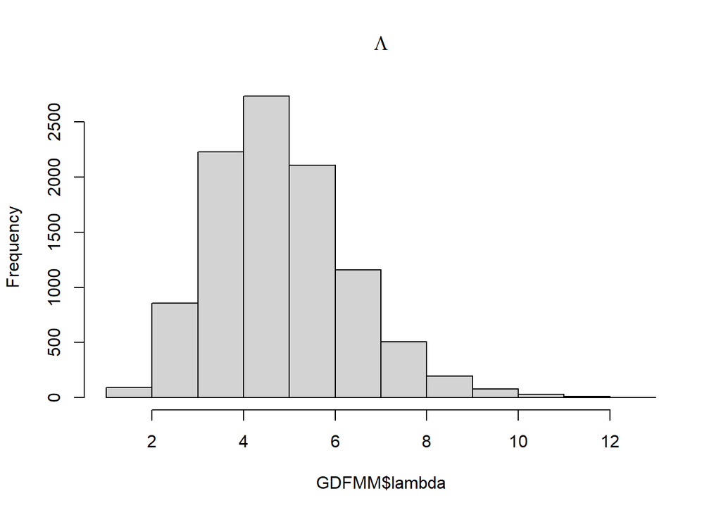

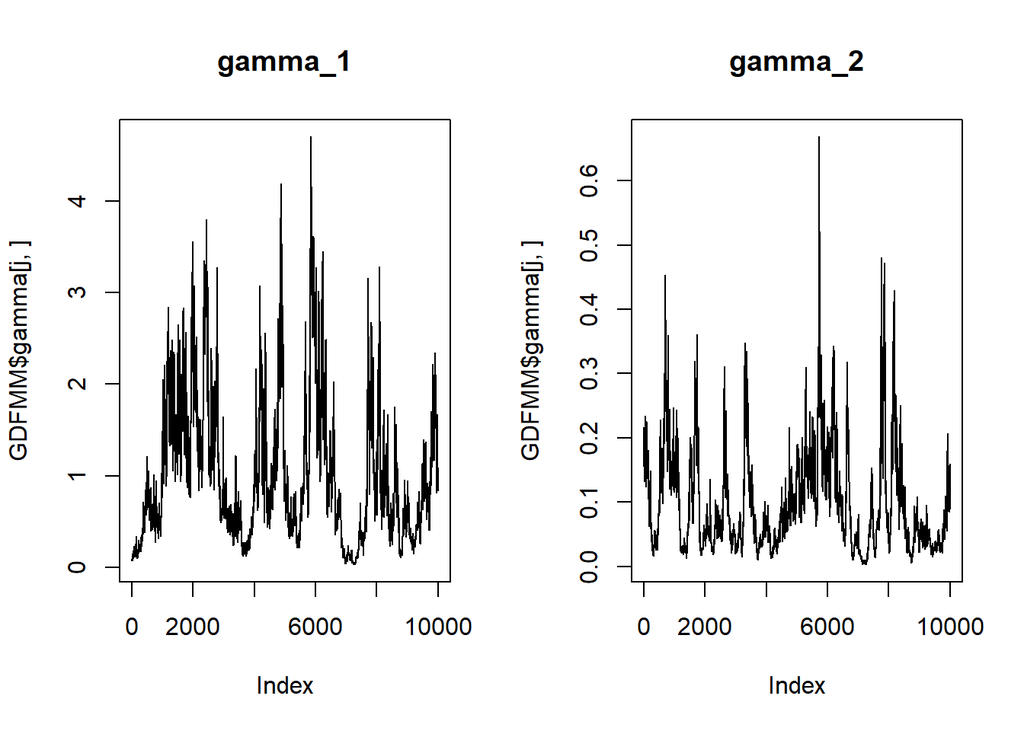

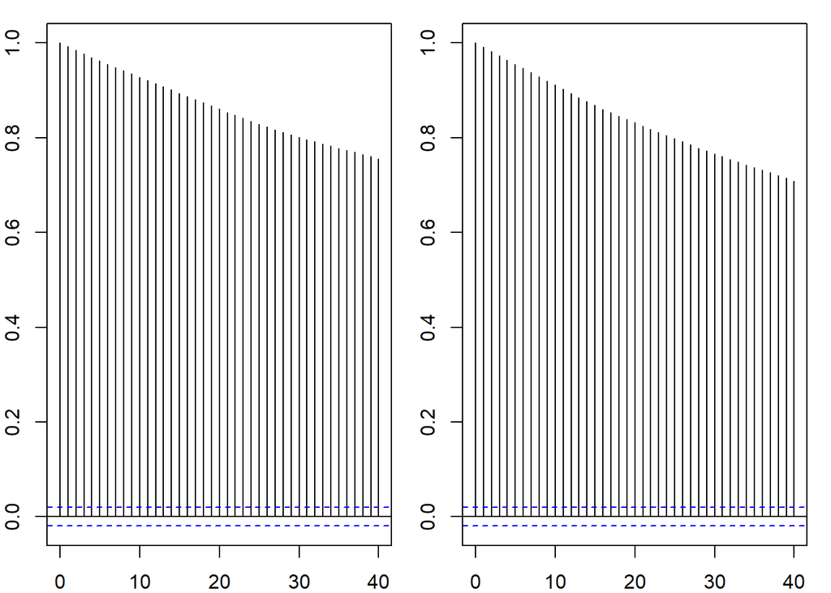

```
#> [1] 0.1686262
```

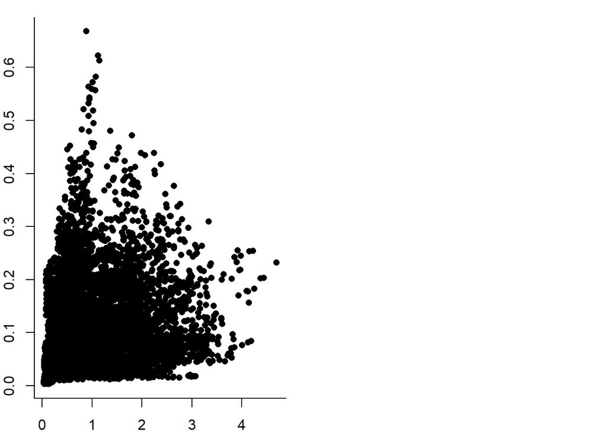

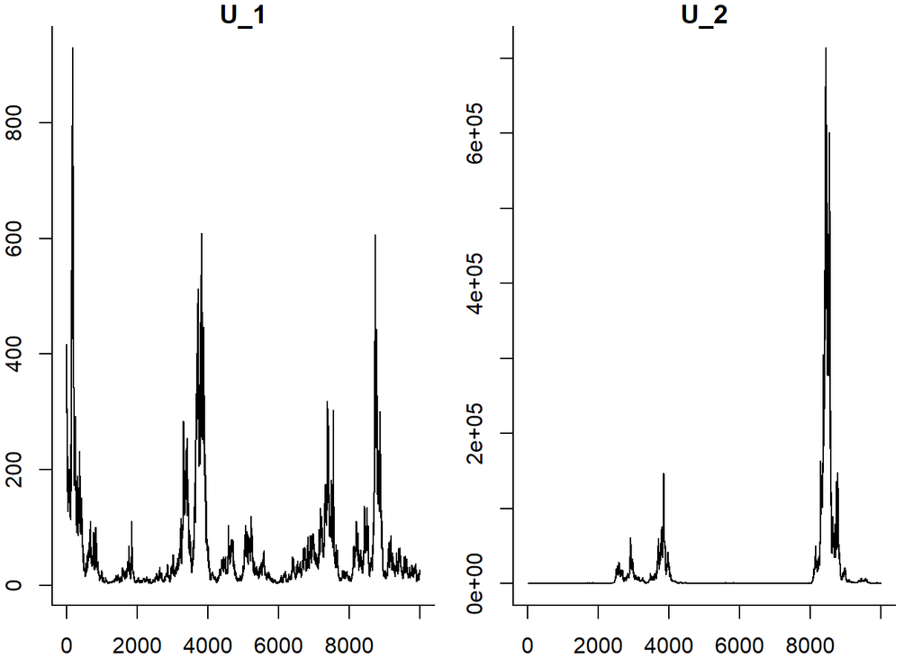

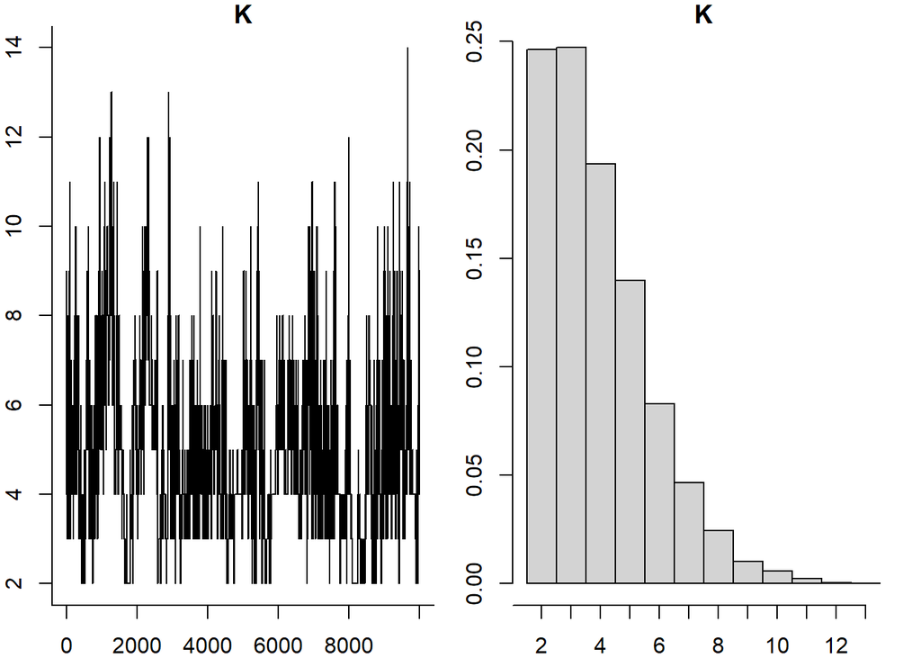

### Clustering

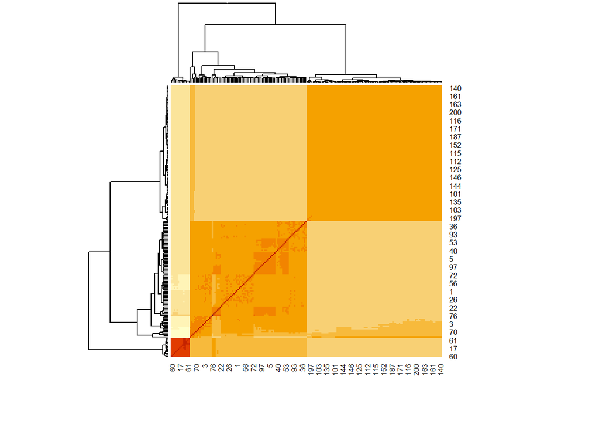

```r
# COMPUTE BINDER LOSS FUNCTION TO SELECT BEST PARTITION

# Get labels for each iterations for each data point
part_matrix <- GDFMM$Partition #GDFMM$Partition is a (n_iter x n_data) matrix

# Compute similarity matrix
sim_matrix <- psm(part_matrix)


heatmap(sim_matrix)
```

```r
binder_sara = minbinder(sim_matrix)
VI_sara = minVI(sim_matrix)

table(binder_sara$cl)
```

```
#>
#>   1   2   3
#>  86  14 100
```

```r
table(VI_sara$cl)
```

```
#>
#>   1   2
#> 186  14
```

```r
table(real_partition)
```

```
#> real_partition
#>  1  2  3
#> 14 93 93
```

```r
arandi(binder_sara$cl,real_partition)
```

```
#> [1] 0.8719571
```

```r
arandi(VI_sara$cl,real_partition)
```

```
#> [1] 0.2073859
```

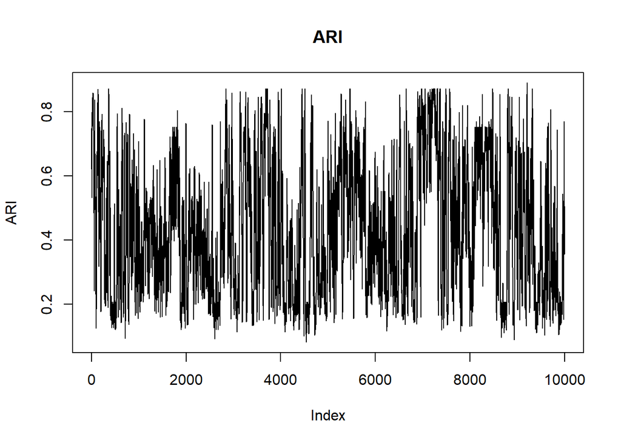

```r
ARI = apply( part_matrix, 1,
             FUN = function(part_it){
                      arandi(part_it,real_partition, adjust = T)
                  }
            )

plot(ARI, type = 'l', main = "ARI")
```

### Density estimation

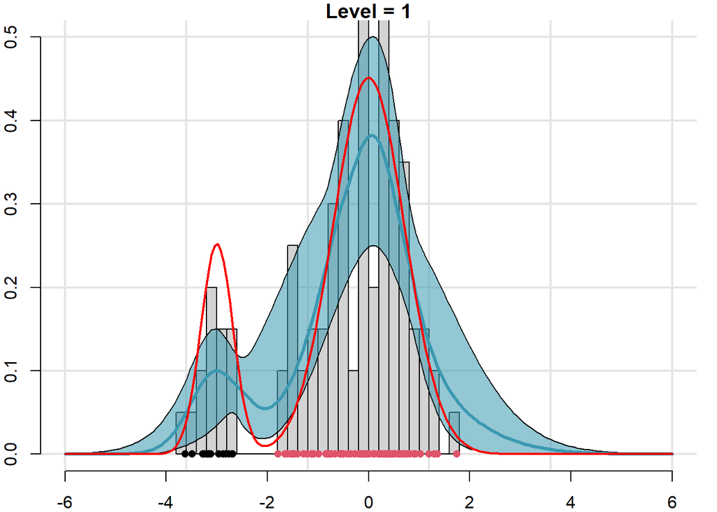

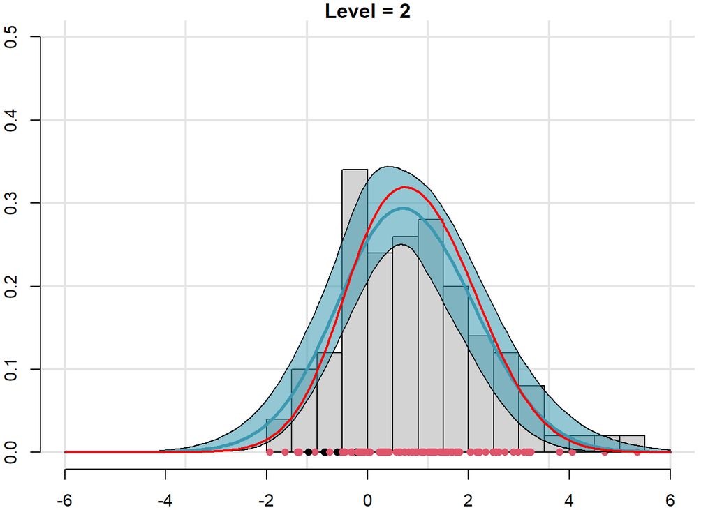

```r
xrange = c(-6,6)
l_grid = 200
grid = seq(xrange[1],xrange[2],length.out = l_grid)
# Predictive in all groups
Pred_all = predictive_marginal_all_groups(grid = grid, fit = GDFMM, burnin = 0, option = option)

# In questo plot sotto colori i pallini secondo il vero cluster.
idx_start = 1
idx_end = n_j[1]


#par(mfrow = c(1,d), mar = c(2,2,1,1))
par(mar = c(2,2,1,1), bty = "l")
for(j in 1:d){

  # set colors
  mycol_cluster = brewer.pal(n=K, name = "Dark2")
  mycol_points  = as.factor(real_partition[idx_start:idx_end])
  levels(mycol_points) = unique(mycol_cluster)

  # frequentist density
  dj = density(data[j,1:n_j[j]])
  yrange = range(Pred_all[[j]][3,]) + 0.001*max(Pred_all[[j]][3,])

  # Trick to add the grid below the plot
  plot.new()
  grid(lty = 1,lwd = 2,col = "gray90" )
  par(new = TRUE)

  # plot
  hist(data[j,1:n_j[j]], freq = F, breaks = n_j[j]/5,
       main = paste0("Level = ",j),
       ylim = c(0,0.5), xlim = xrange,
       ylab = "y-axis", xlab = "x-axis")
  points( x = data[j,1:n_j[j]], y = rep(0,n_j[j]),
          pch = 16, col = mycol_points)
  #lines(dj$x,dj$y, lwd = 3)
  #lines(x = grid, y = Pred_all[[j]][1,], col = "blue", lwd = 2, lty = 2) #0.025
  #lines(x = grid, y = Pred_all[[j]][3,], col = "blue", lwd = 2, lty = 2) #0.975
  polygon( c(grid, rev(grid)),
           c(Pred_all[[j]][1,], rev(Pred_all[[j]][3,])),
           col = ACutils::t_col(mycol[1], percent = 45))
  lines(x = grid, y = Pred_all[[j]][2,], col = mycol[1], lwd = 3) #0.5

  points(grid, GDFMM::dmix(x = grid, w_j = prob[j,], mu_vec = mu, sigma_vec = sd),
         col = "red", lwd = 2, type = "l")

  idx_start = idx_end + 1
    if(j<d){
    idx_end = idx_end + n_j[j+1]
  }
}
```

## Analisi per gruppo

### Primo livello

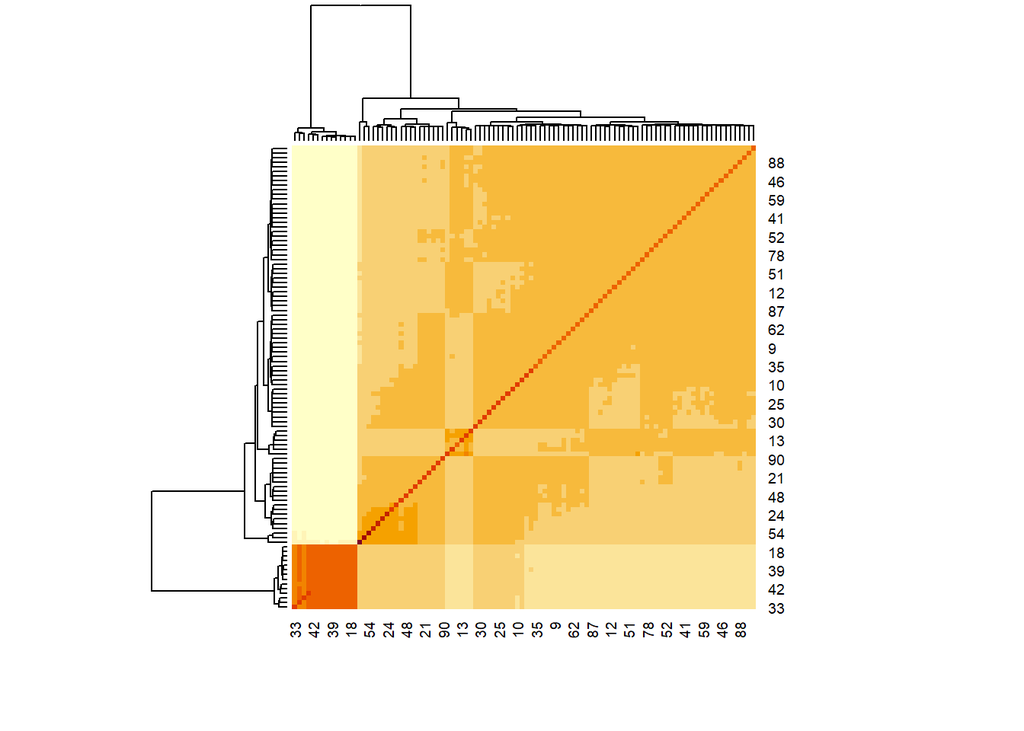

```r
part_matrix_lv1 = part_matrix[,1:n_j[1]]

# Compute similarity matrix
sim_matrix_lv1 <- psm(part_matrix_lv1)

Kest_lv1 = apply(part_matrix_lv1, 1, FUN = function(x){
  x = as.factor(x)
  length(levels(x))
})
#table(Kest_lv1)


heatmap(sim_matrix_lv1)
```

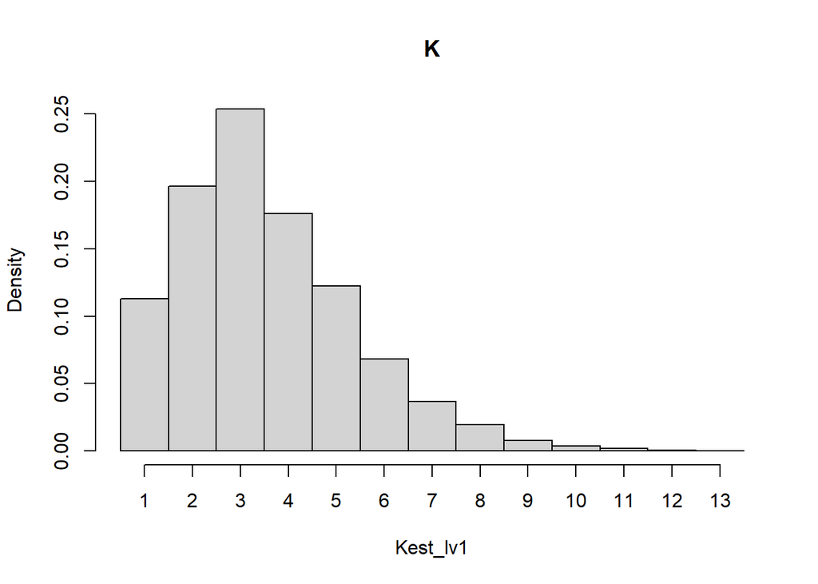

```r
par(bty = "l")
maxK = max(Kest_lv1)-1
hist(Kest_lv1, main = "K",
     breaks = max(Kest_lv1)-1, freq = FALSE,
     xaxt = "n")
axis(1, at = 0.5+(1:maxK), labels = 1:maxK)
```